# HG_Analysis

**MY WEBSITE**

Hunger Games **Text Mining**

The first thing you need will be to import everything you'll need after, particulary the textblop library  
To do that, we have to install the TextBlob library doing the commands below.  
In this cas, we selected an Arsène Wenger sentence who said after an Arsenal game:

```python
#$ pip3 install -U textblob
#$ python3 -m textblob.download_corpora
from textblob import TextBlob

text = "I feel it was an intense gzme where we played against a team who made the game very uncomfortable for us, but we had to be patient and not to make defensive mistakes with their direct game, which we did quite well. But once we were 1-0 up we made it even more complicated by going down to 10 men and then of course it was a bit on the edge. But they didn’t create chances, not many, but they looked dangerous always on set-pieces, on long balls and I felt it was a bit frustrating after we conceded a penalty. Coquelin says he didn’t touch him, but I haven’t seen it, but in the end we still got an unlikely win because when you are 10 against 11 with two minutes to go, it’s difficult to win the game. But we are a team who keeps going no matter what happens and that’s a good quality."
blob = TextBlob(text)
print(text)
```

```
I feel it was an intense gzme where we played against a team who made the game very uncomfortable for us, but we had to be patient and not to make defensive mistakes with their direct game, which we did quite well. But once we were 1-0 up we made it even more complicated by going down to 10 men and …
```

Now that you have seen this little text, let's show how we can analyze it using TextBlob

```python
#import nltk
#nltk.download()

nlpblob = TextBlob(text)
print(nlpblob.sentiment)
print("Polarity:", nlpblob.sentiment.polarity)
print("Subjectivity:", nlpblob.sentiment.subjectivity)
print("Number of sentences:", len(blob.sentences))
#print("Words property", nlpblob.tags) #too long in output
print("Noun sentences:", nlpblob.noun_phrases) #Phrases nominales
print("Word singularize:", nlpblob.words[32], "becomes", nlpblob.words[32].singularize())
print("Word plurialize:", nlpblob.words[12], "becomes", nlpblob.words[12].pluralize())
print("Word lemmatize:", nlpblob.words[9], "is a conjugation of", nlpblob.words[9].lemmatize("v"))
print("Word correction:", nlpblob.words[6], "can be corrected by", nlpblob.words[6].correct(), "and probabilities are", nlpblob.words[6].spellcheck())
#print("Language:", nlpblob.detect_language())
#print("Translation to french:", nlpblob.translate(to="fr"))
```

```
Sentiment(polarity=-0.09475308641975308, subjectivity=0.6104938271604939)
Polarity: -0.09475308641975308
Subjectivity: 0.6104938271604939
Number of sentences: 5
Noun sentences: ['intense gzme', 'defensive mistakes', 'direct game', 'long balls', 'coquelin', 'didn’t touch', 'good quality']
Word singularize: mistakes becomes mistake
Word plurialize: team becomes teams
Word lemmatize: played is a conjugation of play
Word correction: gzme can be corrected by game and probabilities are [('game', 1.0)]
```

For client graphical representations are necessary to show our work, this is why we decided to create a wordcloud of a specific text/book (The Hunger Games).  
The wordcloud will display words most used bigger etc.  
I found this library on 'https://github.com/amueller/word_cloud' so I had to install wordcloud.

[figure not shown]

```python
#$ pip3 install wordcloud
#$ pip3 install Image
import matplotlib.pyplot as plt
from PIL import Image
from os import path
from wordcloud import WordCloud

text = open(path.join('data/The_Hunger_Games.txt'), "r").read()

# Generate a word cloud image
wordcloud = WordCloud().generate(text)
plt.imshow(wordcloud)
plt.axis("off")
plt.show()
```

The first thing we can see is that there is a lot of words in this cloud maybe not meaningful.  
As it's a book of course the 'say' verb appear a lot. Besides there is a lot of verbs (know, will, look, make, come) which useless in our case.  
In order to avoid this problem we will clean our 'The Hunger Games' text.

```python
import re

def clean_text(x):

  # To convert the text in lowercase
  x = x.lower()

  # replace apostrophes
  x = x.replace("'", " ")

  # replace word where len <= 3
  x = re.sub('\\b\\w{1,3}\\s', '', x)

  # remove numbers/Digits
  x = re.sub(r'\d+', '', x)

  # remove white spaces
  x = " ".join(x.split())

  return(x)

len_text_before = len(text)
text = clean_text(text)
print("Size text before:", len_text_before)
print("Size text now:", len(text))


# Display noun phrases
'''nlpblob = TextBlob(text)
textNP = str(nlpblob.noun_phrases)
wordcloud = WordCloud().generate(textNP)
plt.imshow(wordcloud)
plt.axis("off")
plt.show()'''
```

```
Size text before: 521930
Size text now: 380830
```

```
'nlpblob = TextBlob(text)\ntextNP = str(nlpblob.noun_phrases)\nwordcloud = WordCloud().generate(textNP)\nplt.imshow(wordcloud)\nplt.axis("off")\nplt.show()'
```

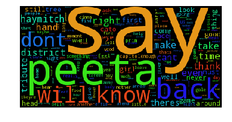

```python
#nlpblob = TextBlob(text)
#textNP = str(nlpblob.noun_phrases)
wordcloud = WordCloud().generate(text)
plt.imshow(wordcloud)
plt.axis("off")
plt.show()
```

Finally, in order to have something more userfriendly and more visible we can easily fix a maximum size for our cloud words.

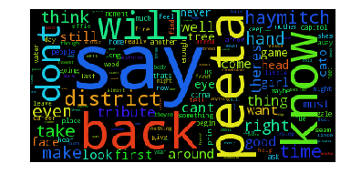

```python
wordcloud = WordCloud(max_font_size=100).generate(text)
plt.figure()
plt.imshow(wordcloud)
plt.axis("off")
plt.show()
```

And to have a beautiful wordcloud we can download a picture (mask) from our movie Hunger Games and display words on our image.

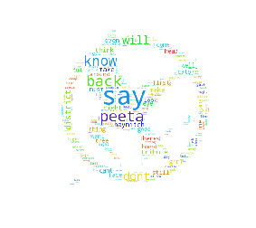

```python
import numpy as np
import matplotlib.pyplot as plt
from nltk.corpus import stopwords

from wordcloud import WordCloud, STOPWORDS
from os import path
from PIL import Image

gemo_mask = np.array(Image.open(path.join("data/The_Hunger_Games.jpg")))

#wc = WordCloud(background_color="white", max_words=1000, mask=gemo_mask, stopwords=stopwords)
wc = WordCloud(background_color="white", max_words=1000, mask=gemo_mask)


# generate word cloud
wc.generate(text)

# show our design wordcloud
plt.imshow(wc)
plt.axis("off")
plt.show()
```